# R Notebook

load libraries #######

```r
library(tidyverse)
library(janitor)
```

load in data ########

```r
customers <- read_csv("data/mall_customers.csv") %>% clean_names()
```

You have been provided some customer data from a shopping centre. Do some exploratory analysis on the data. Comment on findings.

| gender | avg_income |
| --- | --- |
| Female | 59.25000 |
| Male | 62.22727 |

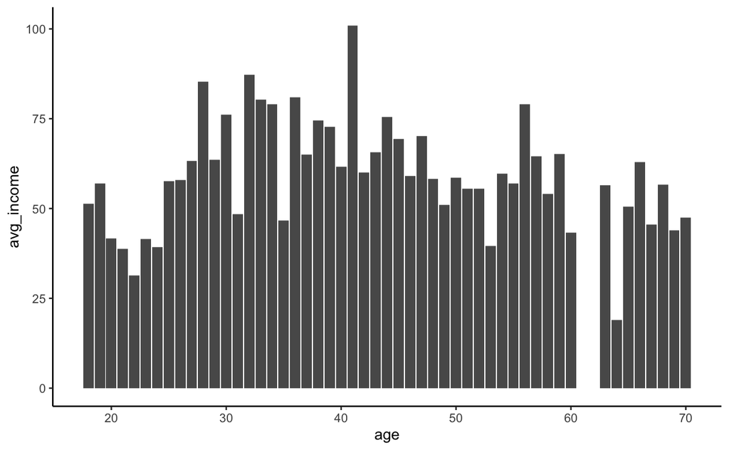

| customer_id | gender | age | annual_income_k | spending_score_1_100 |
| --- | --- | --- | --- | --- |
| 1 | Male | 19 | 15 | 39 |
| 2 | Male | 21 | 15 | 81 |
| 3 | Female | 20 | 16 | 6 |
| 4 | Female | 23 | 16 | 77 |
| 5 | Female | 31 | 17 | 40 |
| 6 | Female | 22 | 17 | 76 |
| 7 | Female | 35 | 18 | 6 |
| 8 | Female | 23 | 18 | 94 |
| 9 | Male | 64 | 19 | 3 |
| 10 | Female | 30 | 19 | 72 |

[output cut: 190 more lines]

We are interested in creating a marketing campaign to target customers based on their spending score and annual income. Perform a k-means clustering to find if there are meaningful clusters in the data to target the customers.

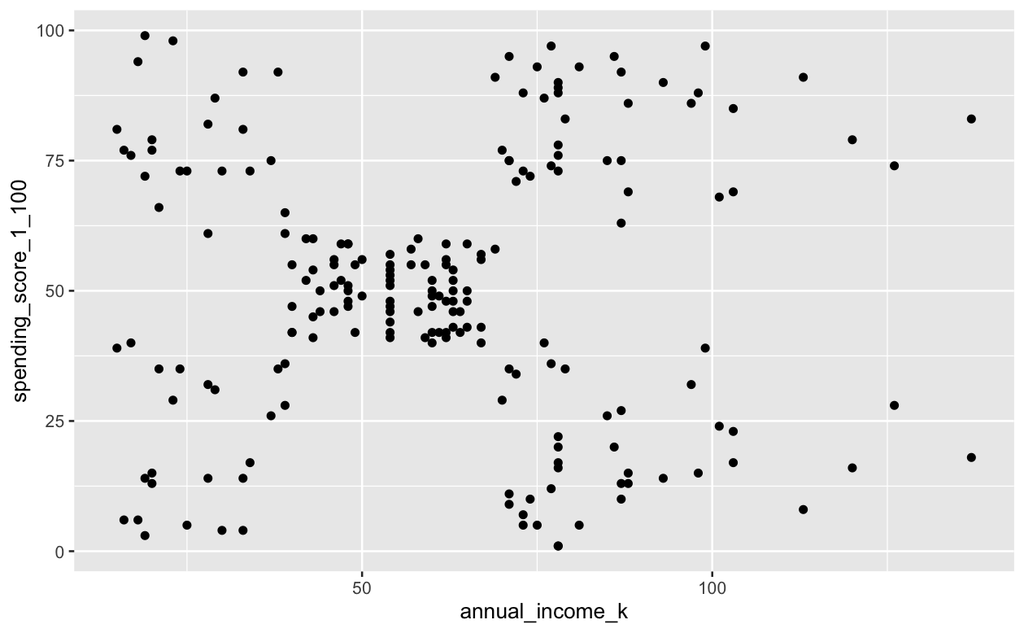

looks like some crazy data

| annual_income_k | spending_score_1_100 |
| --- | --- |
| -1.73464625 | -0.433713114 |
| -1.73464625 | 1.192711064 |
| -1.69657236 | -1.711617825 |
| -1.69657236 | 1.037813523 |
| -1.65849848 | -0.394988729 |
| -1.65849848 | 0.999089138 |
| -1.62042459 | -1.711617825 |
| -1.62042459 | 1.696128071 |
| -1.58235070 | -1.827790981 |
| -1.58235070 | 0.844191597 |

[output cut: 190 more lines]

```r
library(factoextra)
```

first method: **Elbow Method**

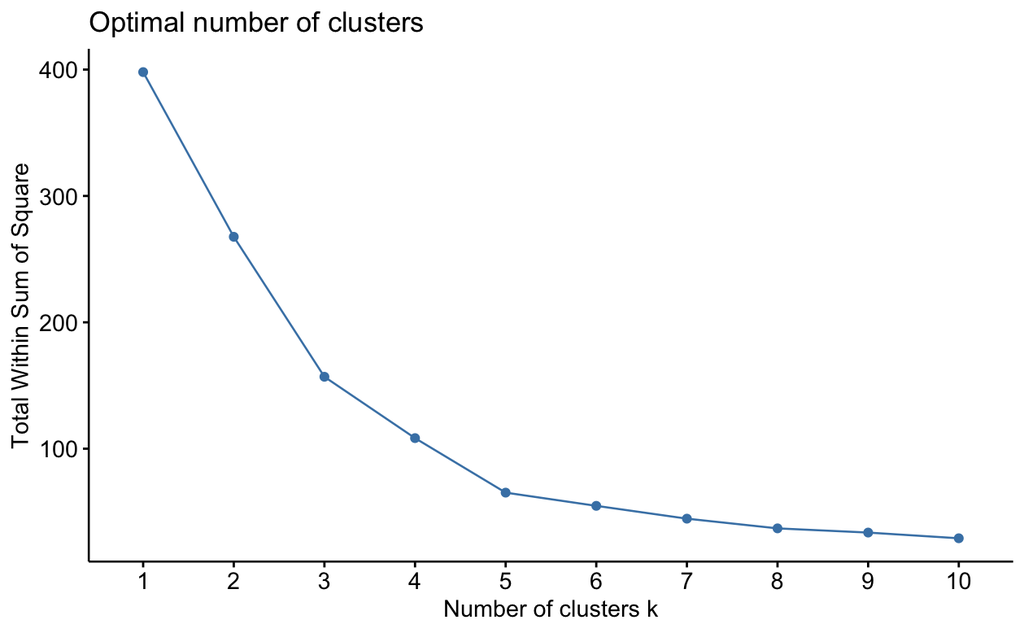

If the line is an arm, where is the elbow? Maybe at k = 2 or k = 3?

Method 2 - **Silhouette Coefficient**

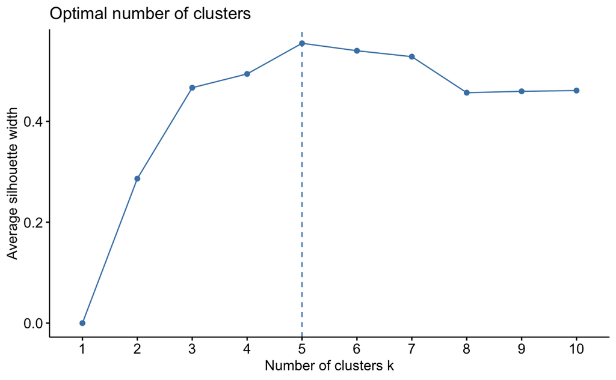

average distance between clusters. Higher means clusters are more distinct.

method 3 - **Gap statistic**

```
Clustering k = 1,2,..., K.max (= 10): .. done
Bootstrapping, b = 1,2,..., B (= 100)  [one "." per sample]:
.................................................. 50
.................................................. 100
```

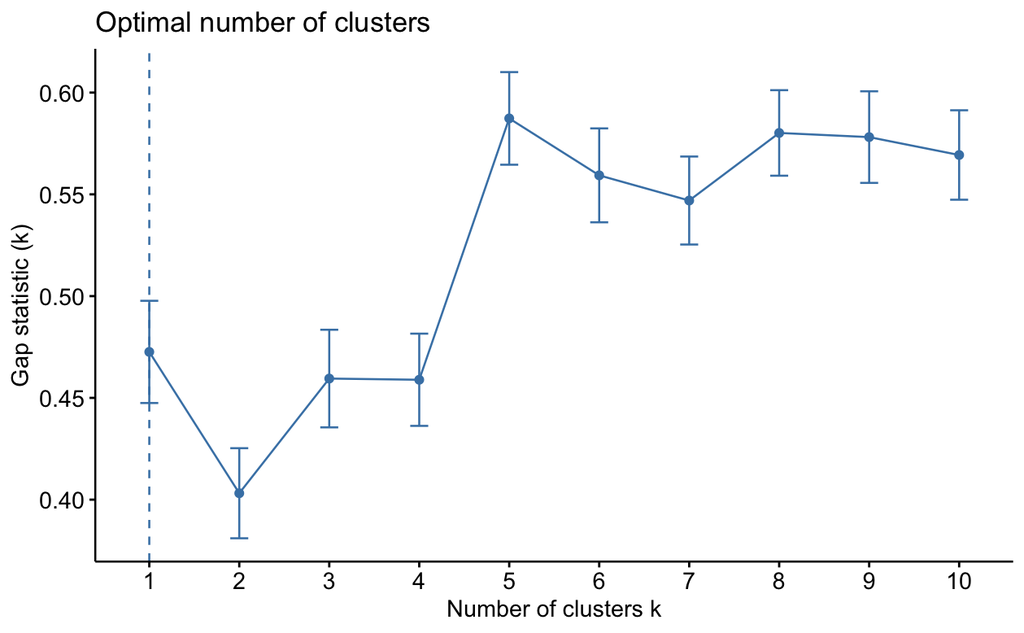

```r
fviz_nbclust(customers_subset,
             kmeans,
             method = "gap",
             nstart = 25)
```

# create the cluster

```r
library(broom)

# look at tidy output (centres)

tidy(cluster)
```

| annual_income_k | spending_score_1_100 | size | withinss | cluster |
| --- | --- | --- | --- | --- |
| 1.0066735 | -1.2224677 | 38 | 20.811888 | 1 |
| -0.4683088 | 0.2431891 | 100 | 60.332163 | 2 |
| 0.9891010 | 1.2364001 | 39 | 19.655252 | 3 |
| -1.3042458 | -1.1341194 | 23 | 7.577407 | 4 |

```r
augment(cluster, customers_subset)
```

| annual_income_k | spending_score_1_100 | .cluster |
| --- | --- | --- |
| -1.73464625 | -0.433713114 | 4 |
| -1.73464625 | 1.192711064 | 2 |
| -1.69657236 | -1.711617825 | 4 |
| -1.69657236 | 1.037813523 | 2 |
| -1.65849848 | -0.394988729 | 4 |
| -1.65849848 | 0.999089138 | 2 |
| -1.62042459 | -1.711617825 | 4 |
| -1.62042459 | 1.696128071 | 2 |
| -1.58235070 | -1.827790981 | 4 |
| -1.58235070 | 0.844191597 | 2 |

[output cut: 190 more lines]

```r
glance(cluster)
```

| totss | tot.withinss | betweenss | iter |
| --- | --- | --- | --- |
| 398 | 108.3767 | 289.6233 | 2 |

```r
NA
NA
```

```r
# customers_subet is the scaled data set
# need to create a data set with the two variables I want

customers_two_var <- customers %>%
  select(annual_income_k, spending_score_1_100)

k_clusters <- tibble(k = 1:20) %>%
  mutate(
    kclust = map(k, ~kmeans(x = customers_subset, centers = .x, nstart = 25)),
    tidied = map(kclust, tidy),
    glanced = map(kclust, glance),
    augmented = map(kclust, ~augment(.x, customers_two_var))
  )

k_clusters
```

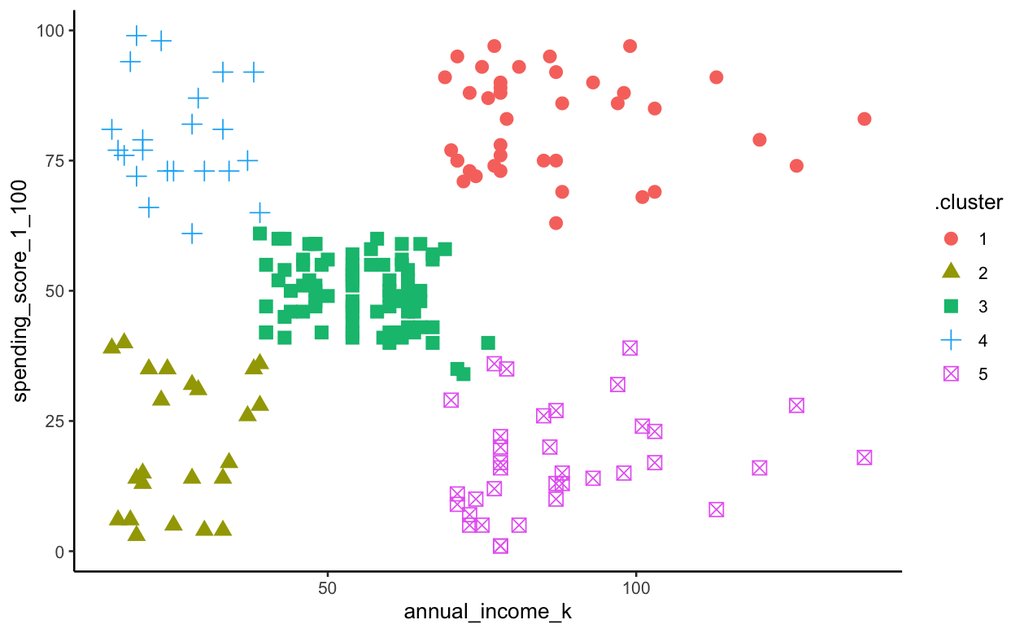

5 clusters seems like a good fit for the data, silhouette method recommended 5

data seems like a good fit for clustering, 5 distinct groups easily binned

labels:

bottom left - low income / low spending score (fiscally responsible) bottom right - high income / low spending score (savers) centre - medium income / medium spending score top left - low income / high spending score (irresponsible spenders) top right - high income / high spenders

Comment on the attributes on one or two of the clusters (maybe even give them a label if you like - like in section 4.1 of the ‘Segmentation & clustering intro’ lesson).